# Custom Plotting Functions for rtsVis

Johannes Mast

2021-05-18

## Introduction

In rtsVis, graphs are created using the `rtsVis::ts_flow_frames()` function. This function takes as inputs a list of raster objects **r_list** (usually preprocessed with `rtsVis::ts_raster()` ) as well as a number of **positions** which can be point or polygon objects of sf or sp. It extracts the raster values intersecting these objects and passes the extracted dataframe **extract_df** to a plotting function, along with a sequence of values **val_seq** which contain plausible values for interval breaks of the values. For every frame, the plotting function is applied to create a ggplot2 object. The output of `rtsVis::ts_flow_frames()` is therefore a list of [ggplot2](https://ggplot2.tidyverse.org/) objects of equal length as the input **r_list**.

## Types of plots

### Spatial Scope

Depending on the type of input geometries, the plots that can plausibly be created can differ.

When using points, the extracted **extract_df** will contain one value per frame and position. This is suitable for plotting of trends and amounts, such as in:

- Scatterplots
- Line Charts
- Bar Charts

When using points with a buffer or polygons as positions, the extracted **extract_df** will usually contain more than one value per frame and position.

This enables plotting of distributions or proportions, for example via:

- Violin Plots
- Histograms
- Pie Charts

We may also be interested in plotting summary statistics for the positions. In this case, we can within apply a summary function such as mean or var within our custom plotting function. We can also pass the FUN directly to `rtsVis::ts_flow_frames()` via the `FUN` parameter, in which case it will be applied during extraction. The statistics can then be plotted in similar ways as the singular values extracted from points.

### Temporal Scope

For some type of plots, we want each frame to provide a snapshot of the data at a certain point in time, without regard for the context the time series provides. This is the case for the violin plot type implemented in `rtsVis`:

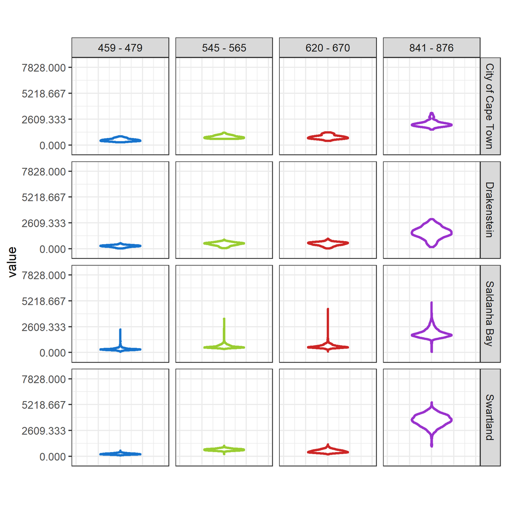

Violin Frames

The temporal dimension can later be brought back in via animation. But every individual frame visualises only one point in time. Contrast that with the line plot type:

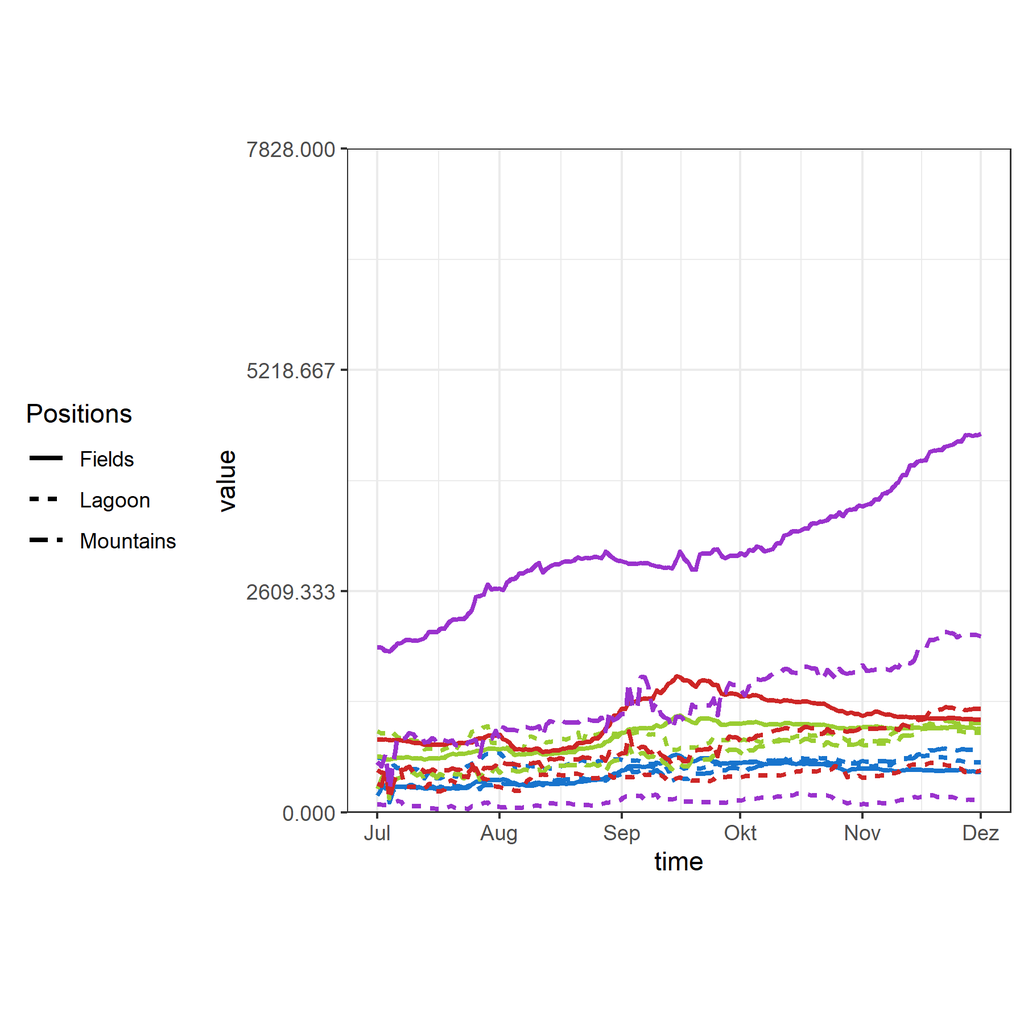

Line Frames

In this type, we visualise not only the value at the current point in time but also all previous values.

Other plot types are conceivable which might visualise future values or points within a time window around the current frame.

## Custom Plotting Functions

### Requirements

Writing a custom plotting function is no more complicated than writing a ggplot. In fact, a ggplot will usually form the main body of such a function. For compatibility with `rtsVis::ts_flow_frames()` we must also consider that it should:

- usually subset the extracted tibble dataframe to be in line with the temporal scope
- return a list of ggplot objects
- accept (and optionally, but ideally also implement) the following arguments, which are prepared by ts_flow_frames:
  - **edf**: The extracted tibble containing values for plotting. The format of this tibble will be discussed in detail in the following section.
  - **pl**: Position legend. A logical value that indicates whether a legend for the positions should be plotted. Only useful if **abp** that is, if any aesthetic is mapped to position.
  - **bl**: Band legend. A logical value that indicates whether a legend for the bands should be plotted.
  - **plt**: Position legend title.
  - **blt**: Band legend title.
  - **lp**: Legend position.
  - **ps**: Plot size. This should be passed to a ggplot geom. As it is treated differently depending on the type of geom, it should sometimes be adjusted by a factor.
  - **vs**: Value sequence. A sequence of values like `c(0,1250,2500,3750,5000)`. This is calculated across all extracted values and allows the user to pass breaks in a value scale.
  - **abp**: Aesthetics by position? A logical value that indicates whether some aesthetic should be mapped to the position. For example, every point could be represented by a different linetype in a line plot.

The plotting function may or may not actually use any of these arguments internally. We recommend to implement as many of them as possible, for consistency with other functions.

The plotting function may also take any number of additional arguments, which can be passed via ellipsis (`...`) when calling `rtsVis::ts_flow_frames()`.

### Input Data Format

```r
extract_df_pt <- readRDS("rtsVis Demo/Data/example__point.rds")[[1]]
val_seq_pt <- readRDS("rtsVis Demo/Data/example__point.rds")[[2]]

head(extract_df_pt,15)
```

```
##    position_name centr_lon centr_lat                time frame      band  value
## 1         Lagoon   1682063  -3686326 2019-07-01 00:00:00     1 620 - 670  499.0
## 2         Lagoon   1682063  -3686326 2019-07-01 00:00:00     1 841 - 876   89.0
## 3         Lagoon   1682063  -3686326 2019-07-01 00:00:00     1 459 - 479  651.0
## 4         Lagoon   1682063  -3686326 2019-07-01 00:00:00     1 545 - 565  957.0
## 5      Mountains   1797136  -3726233 2019-07-01 00:00:00     1 620 - 670  339.0
## 6      Mountains   1797136  -3726233 2019-07-01 00:00:00     1 841 - 876  598.0
## 7      Mountains   1797136  -3726233 2019-07-01 00:00:00     1 459 - 479  197.0
## 8      Mountains   1797136  -3726233 2019-07-01 00:00:00     1 545 - 565  282.0
## 9         Fields   1741777  -3663320 2019-07-01 00:00:00     1 620 - 670  856.0
## 10        Fields   1741777  -3663320 2019-07-01 00:00:00     1 841 - 876 1944.0
## 11        Fields   1741777  -3663320 2019-07-01 00:00:00     1 459 - 479  316.0
## 12        Fields   1741777  -3663320 2019-07-01 00:00:00     1 545 - 565  652.0
## 13        Lagoon   1682063  -3686326 2019-07-01 11:57:51     2 620 - 670  484.0
## 14        Lagoon   1682063  -3686326 2019-07-01 11:57:51     2 841 - 876   89.0
```

[output cut: 17 more lines]

- **position_name**: Character, a position name either passed bei the user or generically generated by`rtsVis::ts_flow_frames()`
- **centr_lon**: Numeric, the longitude of the centroid of the position.
- **centr_lat**: Numeric, the latitude of the centroid of the position.
- **time**: Date, the date of the frame.
- **frame**: Numeric, the number of the current frame. This can be used in conjunction with **i** (see previous section) to select the relevant rows from the tibble.
- **band**: Character, a band name either passed by the user or generically generated by `rtsVis::ts_flow_frames()`
- **value**: Numeric or Integer, the extracted value for this band, position, and frame.
- **band_colors**: Character, a color either passed by the user or generically generated by `rtsVis::ts_flow_frames()`

## Example

Below, we create a plotting function that creates a barchart.

```r
library(ggplot2)
barplot <- function(edf , pl,lp, bl, blt,plt, ps, vs,abp,plot_title){

  # Some checks are usually due
  if(!((edf %>%  dplyr::pull(value) %>% class()) %in% c("integer","numeric") )){
    stop("The value you are attempting to plot is not numeric. Are you sure you want to create a line plot? ")
  }

  # We create a plot for every frame for which we have data.
  # We use lapply for this. It returns a list of frames, one for each level in edf$frame
  out_frames <- rtsVis:::.lapply(1:max(edf$frame), function(i){

    #For the barplot, we only use data from to the current frame (this will be plotted)
    x = edf[edf$frame == i,]
    # Other plots, such as line plots, may show development over time.
    # In these cases we would subset like:
    # x = edf[edf$frame <= i,]

    ## generate base plot
    p <- ggplot(x, aes(x = band,y=value,fill=band))
    ## style it
    p <- p +
      geom_bar(stat = "identity")+
      theme_bw() +
      theme(aspect.ratio = 1) +
      scale_y_continuous( breaks = vs,limits = c(min(vs),max(vs)))+
      theme(legend.position = lp)+
      facet_grid(~position_name)+
      scale_x_discrete(guide = guide_axis(n.dodge = 2))
    #add the colors
    p <- p +
      scale_fill_manual(values = x$band_colors,breaks = x$band, name=blt)

    if(!is.null(plot_title)){
      p <- p+
        ggtitle(label = plot_title)
    }
    return(p)
  } # End the apply over every frame

  )# return the list of created frames
  return(out_frames)
}
```

Once the function is created, we can pass it to `rtsVis::ts_flow_frames` via its `plot_function` argument. `ts_flow_frames` will extract values from rasters and pass them to the newly created barchart plotting function to create a list of barchart frames.

```r
library(sf)
library(rtsVis)
# Read required data
r_list_filled_interpolated <- readRDS("Beispieldaten/MODIS/WesternCape/MODIS_WesternCape_filled_interpolated.rds")
points <- st_read("Beispieldaten/Ancillary/WesternCape/Western_Cape_pts.shp")
points <- st_transform(points, crs = st_crs(r_list_filled_interpolated[[1]]))
#Create the frames
bar_frames <- rtsVis::ts_flow_frames(r_list = r_list_filled_interpolated,
                                      positions = points[c(1,3,4),],
                                      plot_function = barplot,
                                      position_names = points$pointname[c(1,3,4)],
                                      band_names = c("620 - 670","841 - 876","459 - 479","545 - 565"),
                                      band_colors = c("firebrick3","darkorchid3","dodgerblue3","olivedrab3"),
                                      band_legend_title = "Wavelength [nm]",
                                      position_legend = T,
                                      legend_position = "left",
                                      band_legend=T,
                                      aes_by_pos = T,
                                      plot_title="Amazing Plot")
```

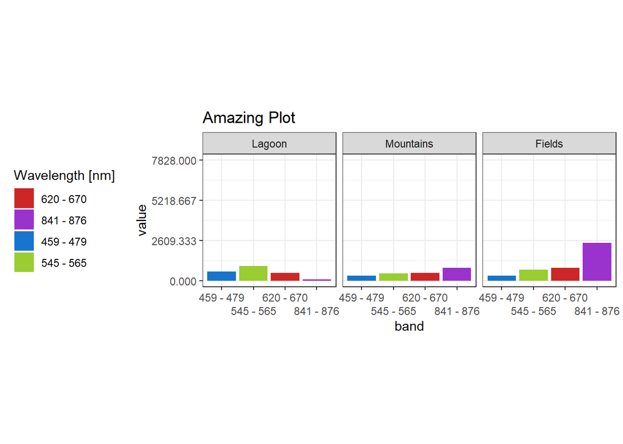

```r
# Examine one of the frames
bar_frames[[50]]
```

We can animate this barchart like any other: Using functionality provided by [moveVis](https://movevis.org/): `animate_frames()`

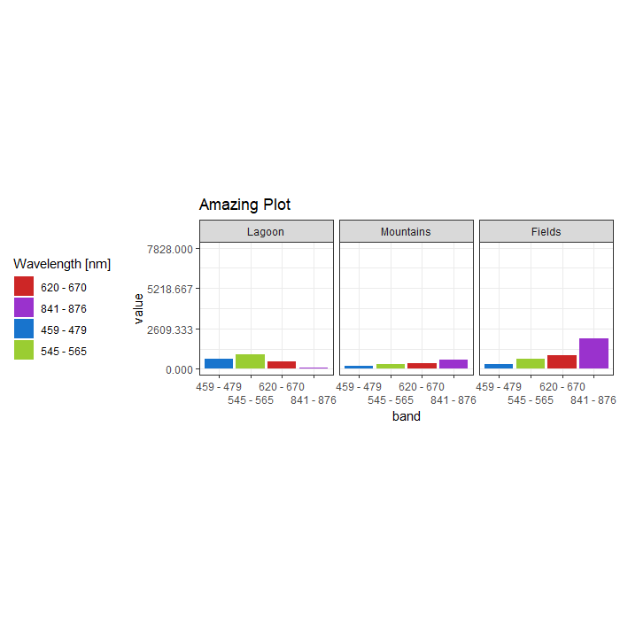

```r
 moveVis::animate_frames(bar_frames,out_file = "Beispielbilder/barplot_anim.gif")
```

## Getting Started

### Example Inputs

The two code chunks below provide examples for typical arguments which the plot function might receive from `rtsVis::ts_flow_frames()`. Among them are two examples for **extract_df** tibbles you can download from the associated repo.

A first step is to extract a test subset for a single frame from the edf, and create a ggplot from that. Once you are happy with the plot, you can wrap it into a plot function and pass it to `ts_flow_frames` for testing.

*Firstly*, a typical environment using values extracted from points.

```r
# Setup for points

#Downloading an example tibble containing data extracted from points
download.file("https://github.com/JohMast/rtsVis_demo/raw/main/Data/example__point.rds",destfile = "extract_df_example_point.rds")
extract_df <- readRDS("rtsVis Demo/Data/example__point.rds")[[1]]
val_seq <- readRDS("rtsVis Demo/Data/example__point.rds")[[2]]

# Typical arguments which the plot function might receive (for testing)
band_legend_title = "Wavelength [nm]"
band_legend=F
position_legend=T
position_legend_title="POIs"
legend_position="left"
path_size=1
aes_by_pos=T



# a test subset of a single frame
x = extract_df[extract_df$frame == 20,]

# # experiment with the plot
# p <- x %>% ggplot(aes_of_your_choice(  ))+
#       geom_of_your_choice()+
#       additional_ggplot_functions()




# Wrap the ggplot code into a plot function
plot_function <- function(edf , pl,lp, bl, blt,plt, ps, vs,abp,plot_title){

  # Part A: Checks and calculations which are valid globally (over all frames)
  # assert_that(makes_sense(input_data))

  # Part B: Create individual frames
  out_frames <- lapply(1:max(edf$frame), function(i){

    #Subset to the data required by a single frame
    x = edf[edf$frame == i,]

    ## generate base plot, for example
    p <- ggplot(x, aes(x = band,y=value,fill=band))

    # further functions to the ggplot 2
    # p <- p +
    #   geom_of_your_choice()+
    #   additional_ggplot_functions()

    #return the single plot
    return(p)
  } # End the apply over every frame

  )# return the list of created frames
  return(out_frames)
}

# Test your new plot function by passing it to rtsVis::ts_flow_frames
flow_frames <- rtsVis::ts_flow_frames(r_list = r_list_filled_interpolated,
                                      positions = points[c(1,3,4),],
                                      plot_function = plot_function,
                                      position_names = points$pointname[c(1,3,4)],
                                      band_names = c("620 - 670","841 - 876","459 - 479","545 - 565"),
                                      band_colors = c("firebrick3","darkorchid3","dodgerblue3","olivedrab3"),
                                      band_legend_title = "Wavelength [nm]",
                                      position_legend = T,
                                      legend_position = "left",
                                      band_legend=T,
                                      aes_by_pos = T,
                                      plot_title="Amazing Plot")
#Examine one frame
flow_frames[[50]]
```

Secondly, you could also use values extracted from polygons (as in the default violin plot):

```r
# Setup for Polygons
# Downloading an example tibble containing data extracted from polygons
download.file("https://github.com/JohMast/rtsVis_demo/raw/main/Data/example__polygon.rds")

extract_df <- readRDS("extract_df_example_polygon.rds")[[1]]
val_seq <- readRDS("extract_df_example_polygon.rds")[[2]]
band_legend_title = "Wavelength [nm]"
band_legend=F
position_legend=T
position_legend_title="AOIs"
legend_position="left"
plot_size=1
aes_by_pos=T



# a test subset
x = extract_df[extract_df$frame == 20,]

p <- x %>% ggplot(aes_of_your_choice(  ))+
      geom_of_your_choice()+
      additional_ggplot_functions()




plot_function <- function(edf , pl,lp, bl, blt,plt, ps, vs,abp,plot_title){

  # Part A: Checks and calculations which are valid globally (over all frames)

  # Part B: Create individual frames
  out_frames <- lapply(1:max(edf$frame), function(i){

    #Subset to the data required by a single frame
    x = edf[edf$frame == i,]

    ## generate base plot, for example
    p <- ggplot(x, aes(x = band,y=value,fill=band))

    # further functions to the ggplot 2
    # p <- p +
    #   geom_of_your_choice()+
    #   additional_ggplot_functions()

    #return the single plot
    return(p)
  } # End the apply over every frame

  )# return the list of created frames
  return(out_frames)
}

#Create the frames using your new plotting function
flow_frames <- rtsVis::ts_flow_frames(r_list = r_list_filled_interpolated,
                                      positions = points[c(1,3,4),],
                                      plot_function = plot_function,
                                      position_names = points$pointname[c(1,3,4)],
                                      band_names = c("620 - 670","841 - 876","459 - 479","545 - 565"),
                                      band_colors = c("firebrick3","darkorchid3","dodgerblue3","olivedrab3"),
                                      band_legend_title = "Wavelength [nm]",
                                      position_legend = T,
                                      legend_position = "left",
                                      band_legend=T,
                                      aes_by_pos = T,
                                      plot_title="Amazing Plot")
#Examine one frame
flow_frames[[50]]
```

### Information on Data Visualisation

There are many ways to visualize data. Check out Claus Wilke’s excellent [book](https://clauswilke.com/dataviz/) which deals with the most important types and common pitfalls of data visualization.

For inspiration, visit the [r-graph-gallery](https://www.r-graph-gallery.com/)!